[figure not shown]

# Project Title :

## Future Sales prediction of an online computer hardware company

#### Problem Statement:

The company plans to increase their sales for the upcoming year. They have gathered their sales data of past 3 years which contains information reagrding customer purchase history like name, state, product name, product category, product cost, sales, quantity, total cost and total sales. By utilising the data, they want to increase the sales eventaully maximise the profit by reducing the costs.

The machine learning task includes applying regression tasks to the provided data and train suitable models. Finally the model with best accuracy will be selected and the best model will be checked by visualising.

The link ['Click Here'](https://www.kaggle.com/datasets/ayushparwal2026/online-ecommerce/download?datasetVersionNumber=1)

```python
import pandas as pn
import seaborn as sa
import matplotlib.pyplot as mt
import numpy as mp
import warnings
warnings.filterwarnings('ignore')
from feature_engine.outliers import Winsorizer as Wins
from sklearn.preprocessing import StandardScaler, OneHotEncoder
from sklearn.compose import ColumnTransformer as CT
from sklearn.pipeline import Pipeline as pp
from sklearn.model_selection import train_test_split as tts
from sklearn.model_selection import GridSearchCV as gds
from sklearn.linear_model import LinearRegression as lrg
from sklearn.ensemble import RandomForestRegressor as rfr
from sklearn.metrics import mean_squared_error
from sklearn.ensemble import GradientBoostingRegressor as gb1
from sklearn.svm import SVR as vr
from sklearn.metrics import r2_score as sc
```

## Uploading and exmaine the Dataset

```python
sales_df = pn.read_csv("OnlineData.csv")
```

```python
sales_df.head(10)
```

|  | Order_Number | State_Code | Customer_Name | Order_Date | Status | Product | Category | Brand | Cost | Sales | Quantity | Total_Cost | Total_Sales | Assigned Supervisor |
| --- | --- | --- | --- | --- | --- | --- | --- | --- | --- | --- | --- | --- | --- | --- |
| 0 | 139374.0 | AP | Adhir Samal | 11/01/2020 | Delivered | 512 GB M.2 | SSD | Samsung | 6500.0 | 8450.0 | 1.0 | 6500.0 | 8450.0 | Ajay Sharma |
| 1 | 139375.0 | AP | Dannana Jhammi | 11/01/2020 | Delivered | RYZEN 3rd gen. 3500 | CPU | Intel | 8500.0 | 11050.0 | 3.0 | 25500.0 | 33150.0 | Roshan Kumar |
| 2 | 139376.0 | AS | Vipin Kumar | 11/01/2020 | Delivered | 2GB Graphic Card | Graphic Card | Nvidia | 7000.0 | 9100.0 | 2.0 | 14000.0 | 18200.0 | Aarvi Gupta |
| 3 | 139377.0 | BR | Ranjeet Kumar | 11/01/2020 | Delivered | 16 GB DDR4 RAM | RAM | Hynix | 6550.0 | 8515.0 | 3.0 | 19650.0 | 25545.0 | Vijay Singh |
| 4 | 139378.0 | CG | Sajal Singhal | 11/01/2020 | Order | Standard ATX motherboard | MotherBoard | Gigabyte | 7650.0 | 9945.0 | 4.0 | 30600.0 | 39780.0 | Aadil Khan |
| 5 | 139379.0 | CG | Akhilesh Kumar | 11/01/2020 | Order | Compact with 1 Fan | Cabinet | Asus | 1150.0 | 1495.0 | 2.0 | 2300.0 | 2990.0 | Advika Joshi |
| 6 | 139380.0 | CG | Suvankar Chakraborty | 11/01/2020 | Order | USB Backlight Keyboard | Keyboard | Dell | 850.0 | 1105.0 | 3.0 | 2550.0 | 3315.0 | Ajay Sharma |
| 7 | NaN | NaN | NaN | NaN | NaN | NaN | NaN | NaN | NaN | NaN | NaN | NaN | NaN | NaN |
| 8 | NaN | NaN | NaN | NaN | NaN | NaN | NaN | NaN | NaN | NaN | NaN | NaN | NaN | NaN |
| 9 | 139381.0 | CG | Suvankar Adhikary | 12/01/2020 | Order | Ergonomic Mouse | Mouse | Samsung | 650.0 | 845.0 | 2.0 | 1300.0 | 1690.0 | Ajay Sharma |

# Data Exploration

## Examining the datatype

```python
sales_df.dtypes
```

```
Order_Number           float64
State_Code              object
Customer_Name           object
Order_Date              object
Status                  object
Product                 object
Category                object
Brand                   object
Cost                   float64
Sales                  float64
Quantity               float64
Total_Cost             float64
Total_Sales            float64
Assigned Supervisor     object
dtype: object
```

## Examining the Diamension

```python
sales_df.shape
```

```
(5110, 14)
```

## Examing the Null Values

```python
sales_df.isnull().sum().sum()
```

```
210
```

## Examine Duplicates

```python
duplicate_values = sales_df.apply(lambda x: x.duplicated().any())
print(duplicate_values[duplicate_values == True])
```

```
Order_Number           True
State_Code             True
Customer_Name          True
Order_Date             True
Status                 True
Product                True
Category               True
Brand                  True
Cost                   True
Sales                  True
Quantity               True
Total_Cost             True
Total_Sales            True
Assigned Supervisor    True
dtype: bool
```

## Data Visualisation

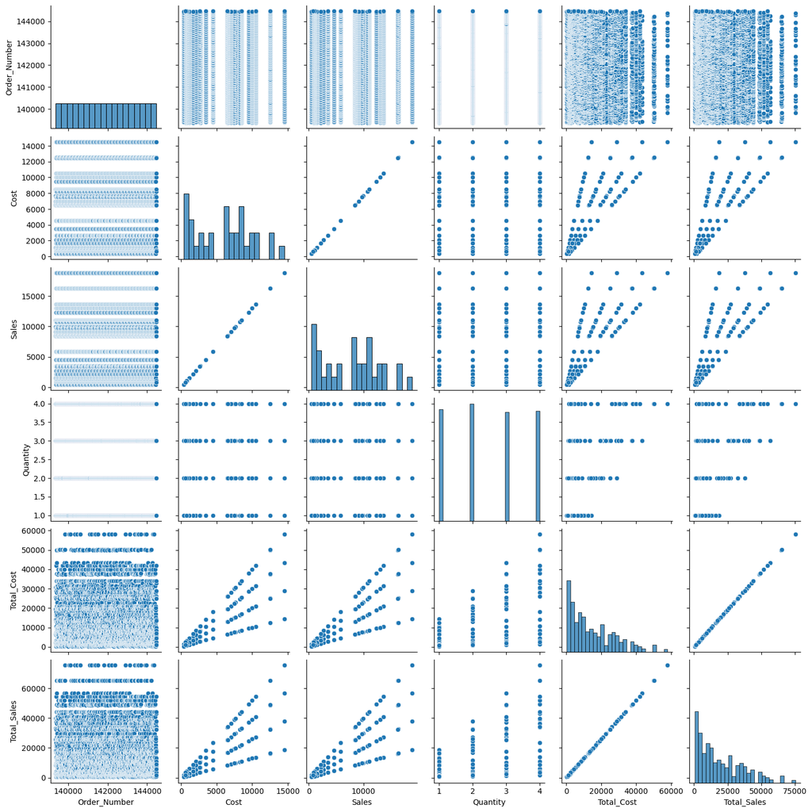

```python
sa.pairplot(sales_df)
```

# Data Preprocessing and Feature Engineering

## Removing Null Values

```python
sales_df.dropna(inplace=True)
sales_df.isnull().sum().sum()
```

```
0
```

## Removing Duplicate Values

```python
sales_df.drop_duplicates(inplace=True)
sales_df.duplicated().sum()
```

```
0
```

## Oulier Analysis

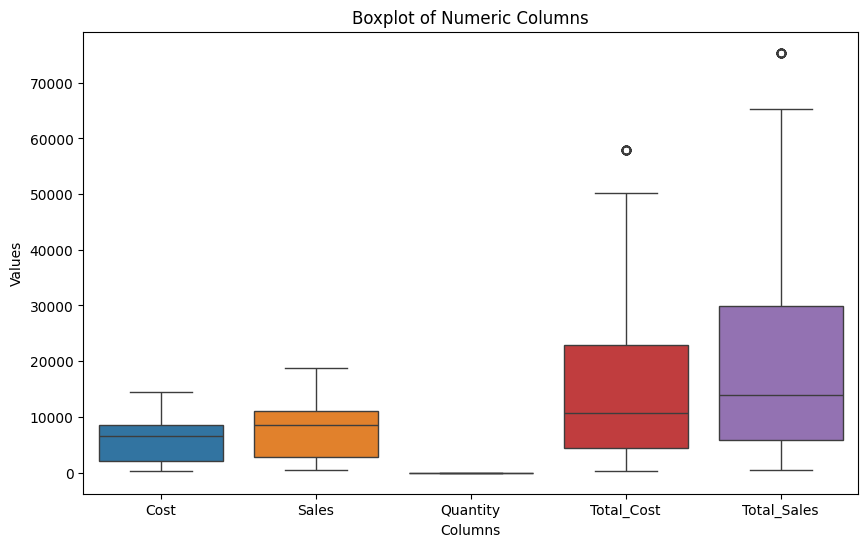

```python
acols = ['Cost', 'Sales', 'Quantity', 'Total_Cost', 'Total_Sales']

mt.figure(figsize=(10, 6))
sa.boxplot(data=sales_df[acols])
mt.title('Boxplot of Numeric Columns')
mt.xlabel('Columns')
mt.ylabel('Values')
mt.show()
```

### We can see that there are some outliers. so we have to remove this outlier by using winsorizer method.

```python
winso = Wins(tail='both', capping_method='iqr', fold=1.5, variables=acols)

winso.fit(sales_df)

sales_df = winso.transform(sales_df)
```

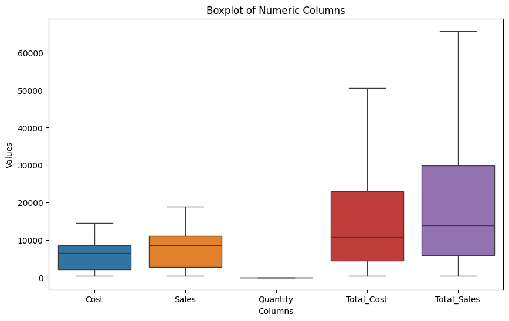

```python
mt.figure(figsize=(10, 6))
sa.boxplot(data=sales_df[acols])
mt.title('Boxplot of Numeric Columns')
mt.xlabel('Columns')
mt.ylabel('Values')
mt.show()
```

### After using winsorizer method outlires has been removed.

## Removing column with nominal values

```python
columns = ['Order_Number', 'Customer_Name', 'Order_Date']
sales_df.drop(columns, axis=1, inplace=True)
```

```python
columns = ['State_Code', 'Status', 'Product', 'Category', 'Brand', 'Cost', 'Sales', 'Quantity', 'Total_Cost', 'Assigned Supervisor']
variable = 'Total_Sales'

v = sales_df[columns]
c = sales_df[variable]
```

## Division of data

```python
v_train, v_test, c_train, c_test = tts(v, c,  random_state=42, test_size=0.2)
```

```python
acols = ['Cost', 'Sales', 'Quantity', 'Total_Cost']
ctg = ['State_Code', 'Status', 'Product', 'Category', 'Brand', 'Assigned Supervisor']

nt = StandardScaler()
cc = OneHotEncoder(handle_unknown='ignore')

Transfer = CT(transformers=[ ('num', nt, acols), ('cat', cc, ctg)])

v_train = Transfer.fit_transform(v_train)
v_test = Transfer.transform(v_test)
```

# Building of Models

## Linear Regreesion

```python
linreg_model = lrg()
linreg_model.fit(v_train, c_train)
```

```
LinearRegression()
```

## Random Forest

```python
rf_model = rfr()

pg = { 'n_estimators': [50, 100], 'min_samples_split' : [None, 2], 'max_depth': [None, 10], 'min_samples_leaf' : [None, 1]}

gs = gds(rf_model, pg, cv=5, scoring='neg_mean_squared_error')

gs.fit(v_train, c_train)
```

```
GridSearchCV(cv=5, estimator=RandomForestRegressor(),
             param_grid={'max_depth': [None, 10], 'min_samples_leaf': [None, 1],
                         'min_samples_split': [None, 2],
                         'n_estimators': [50, 100]},
             scoring='neg_mean_squared_error')
```

## Gradient Boosting

```python
gb_model = gb1()

pg_gb = {'max_depth': [3, 5], 'n_estimators': [60, 120],}

gsg = gds(gb_model, pg_gb, cv=3, scoring='neg_mean_squared_error')

gsg.fit(v_train, c_train)
```

```
GridSearchCV(cv=3, estimator=GradientBoostingRegressor(),
             param_grid={'max_depth': [3, 5], 'n_estimators': [60, 120]},
             scoring='neg_mean_squared_error')
```

## Support Vector Machine Model

```python
svm_model = vr()
pg_gb = {'kernel': ['linear', 'rbf'], 'C': [0.1, 2, 11],  'epsilon': [0.2, 0.3, 0.6]}

gsg = gds(svm_model,  pg_gb, cv=3, scoring='neg_mean_squared_error')

gsg.fit(v_train, c_train)
```

```
GridSearchCV(cv=3, estimator=SVR(),
             param_grid={'C': [0.1, 2, 11], 'epsilon': [0.2, 0.3, 0.6],
                         'kernel': ['linear', 'rbf']},
             scoring='neg_mean_squared_error')
```

## Ditecting Accuracy

```python
y_pr_lin = linreg_model.predict(v_test)
r2_li_re = sc(c_test, y_pr_lin)
print(" Linear Regression R-squared score:", r2_li_re)

y_p_r = gs.best_estimator_.predict(v_test)
r2_r = sc(c_test, y_p_r)
print("R2 Score for Random Forest:", r2_r)

y_pr_gb = gsg.best_estimator_.predict(v_test)
r2_gb = sc(c_test, y_pr_gb)
print("R2 Score for Gradient Boosting:", r2_gb)

y_pr_svm = gsg.best_estimator_.predict(v_test)
r2_svm = sc(c_test, y_pr_svm)
print("R2 Score for Support Vector Machine:", r2_svm)
```

```
 Linear Regression R-squared score: 0.9999999999650392
R2 Score for Random Forest: 1.0
R2 Score for Gradient Boosting: 0.9958638543338796
R2 Score for Support Vector Machine: 0.9958638543338796
```

#### Here we have firstly trained and tested the model then used various machine learning algorithm and find R2 square of each algorithm .

## Checking the best model

```python
R = {'Linear Regression': r2_li_re,'Random Forest': r2_r,'Gradient Boosting': r2_gb,'Support Vector Machine': r2_svm}

best_model = max(R, key=R.get)
print(f'The best model is: {best_model} with an R2 score of {R[best_model]}')
```

```
The best model is: Random Forest with an R2 score of 1.0
```

#### From the above results we have calculated and compaired the various algorithms and found random forest as a best model.

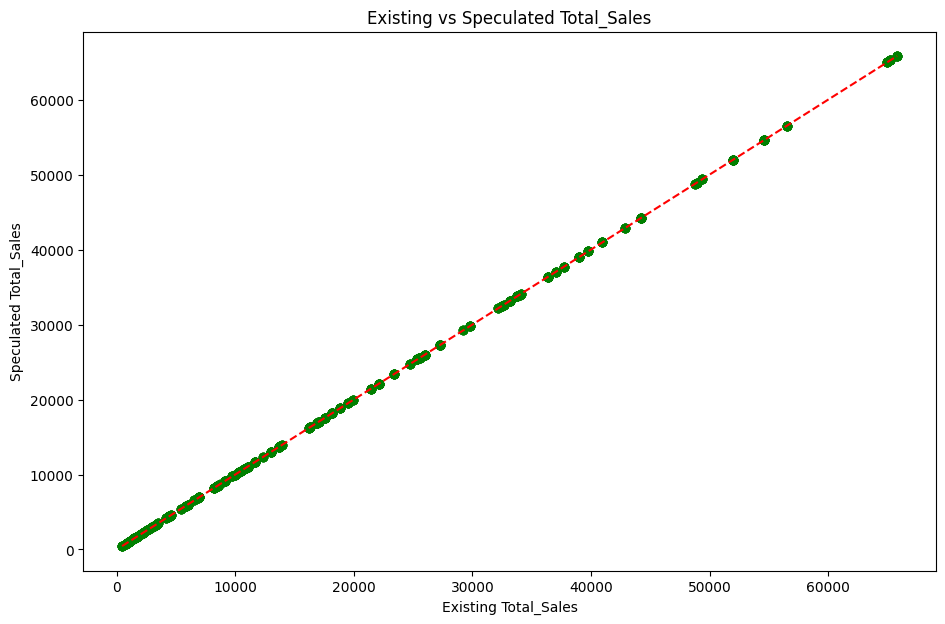

```python
mt.figure(figsize=(11, 7))
mt.scatter(c_test, y_p_r, label='Random Forest', color='green')
mt.plot([min(c_test), max(c_test)], [min(c_test), max(c_test)], '--', color='red')
mt.xlabel('Existing Total_Sales')
mt.ylabel('Speculated Total_Sales')
mt.title('Existing vs Speculated Total_Sales')
mt.show()
```

### From above graph we have calculated actual as well as predicted total sales. These plot tells us that the trained model has great predicting accuracy and hence it can be used for predicting future sales.

# Conclusion

## In the above charts and graphs we can observe that Random Forest has the best accuracy of 1. we can also observe that total sales is more than total cost therefore the bussiness is running in a good position.